# Chapter3

practising123

16 tammikuuta 2019

# Chapter 3 - Logistic regression

- Did the dataCamp exercises.

3.1 & 3.2

```r
library(GGally)
library(dplyr)
library(tidyr)
library(ggplot2)
alc <- read.table("data/alc.csv",header = TRUE)
colnames(alc)
```

```
##  [1] "school"     "sex"        "age"        "address"    "famsize"
##  [6] "Pstatus"    "Medu"       "Fedu"       "Mjob"       "Fjob"
## [11] "reason"     "nursery"    "internet"   "guardian"   "traveltime"
## [16] "studytime"  "failures"   "schoolsup"  "famsup"     "paid"
## [21] "activities" "higher"     "romantic"   "famrel"     "freetime"
## [26] "goout"      "Dalc"       "Walc"       "health"     "absences"
## [31] "G1"         "G2"         "G3"         "alc_use"    "high_use"
```

The data is combination of two guestionaires made in portugal about school performance and alcohol usage. The two tables are combined to alc, data has 35 variables and 382 observations. Downloading the data and more information here: the tables are Student performansce data that can be studied or downloaded here: https://archive.ics.uci.edu/ml/datasets/Student+Performance . In addition: - The variables not used for joining the two data have been combined by averaging (including the grade variables) - ‘alc_use’ is the average of ‘Dalc’ and ‘Walc’ - ‘high_use’ is TRUE if ‘alc_use’ is higher than 2 and FALSE otherwise

3.3 The 4 hypothesis and interesting varibles I chose to explore are: absences, My guess is that more absences from school would lead to higher alcohol use because of lower grades and “rebellious” nature of the person. sex, hypothesis is that male will drink heavier than female. pstatus, hypothesis is that child of a divorced parents is more likely to be high user. G3(final grade) hypothesis is that high users are likely to get lower final score than low users. 3.4

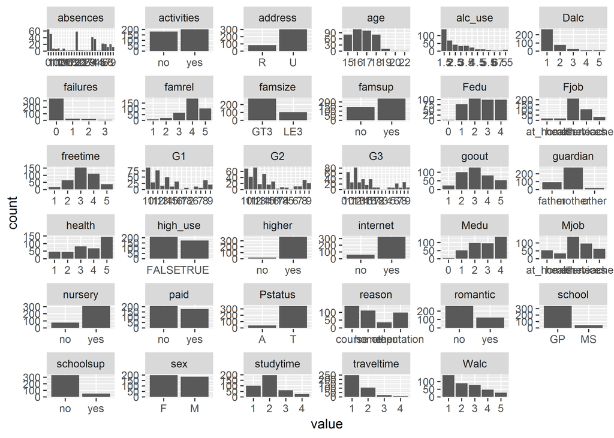

```r
gather(alc) %>% ggplot(aes(value)) + facet_wrap("key", scales = "free") + geom_bar()
```

```r
alc %>% group_by(high_use, absences) %>% summarise(count = n())
```

```
## # A tibble: 42 x 3
## # Groups:   high_use [?]
##    high_use absences count
##    <lgl>       <int> <int>
##  1 FALSE           0    43
##  2 FALSE           1    29
##  3 FALSE           2    33
##  4 FALSE           3    28
##  5 FALSE           4    19
##  6 FALSE           5    11
##  7 FALSE           6    13
##  8 FALSE           7     5
##  9 FALSE           8     9
## 10 FALSE           9     4
## # ... with 32 more rows
```

```r
alc %>% group_by(high_use, sex) %>% summarise(count = n())
```

```
## # A tibble: 4 x 3
## # Groups:   high_use [?]
##   high_use sex   count
##   <lgl>    <fct> <int>
## 1 FALSE    F       129
## 2 FALSE    M        79
## 3 TRUE     F        69
## 4 TRUE     M       105
```

```r
alc %>% group_by( Pstatus, high_use) %>% summarise(count = n())
```

```
## # A tibble: 4 x 3
## # Groups:   Pstatus [?]
##   Pstatus high_use count
##   <fct>   <lgl>    <int>
## 1 A       FALSE       24
## 2 A       TRUE        14
## 3 T       FALSE      184
## 4 T       TRUE       160
```

```r
alc %>% group_by(G3, high_use) %>% summarise(count = n())
```

```
## # A tibble: 32 x 3
## # Groups:   G3 [?]
##       G3 high_use count
##    <int> <lgl>    <int>
##  1     0 TRUE         2
##  2     2 TRUE         1
##  3     3 FALSE        1
##  4     4 FALSE        2
##  5     4 TRUE         5
##  6     5 FALSE        4
##  7     5 TRUE         2
##  8     6 FALSE       13
##  9     6 TRUE         9
## 10     7 FALSE        2
## # ... with 22 more rows
```

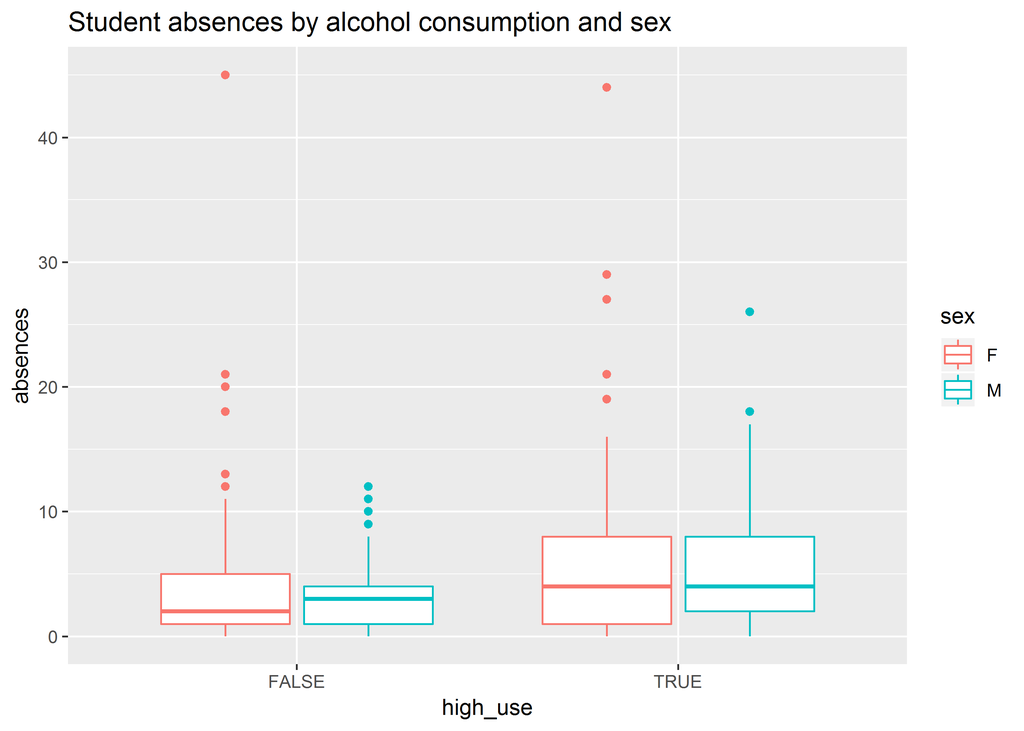

```r
g1 <- ggplot(alc, aes(x = high_use, y = absences, col=sex))
g1 + geom_boxplot() + ggtitle("Student absences by alcohol consumption and sex")
```

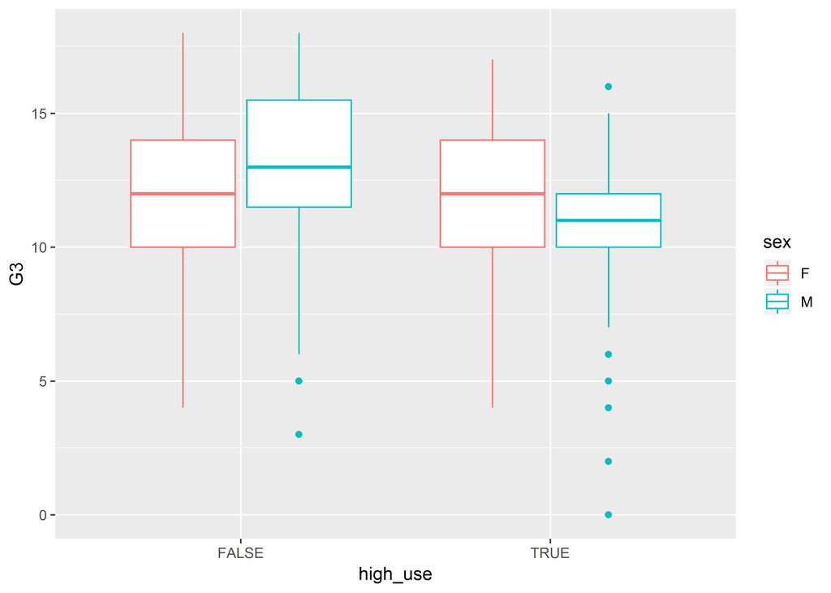

```r
g2 <- ggplot(alc, aes(x = high_use, y = G3, col=sex))
g2 + geom_boxplot()
```

```r
m <- glm(high_use ~ absences + sex + Pstatus + G3, data = alc, family = "binomial")
summary(m)
```

```
##
## Call:
## glm(formula = high_use ~ absences + sex + Pstatus + G3, family = "binomial",
##     data = alc)
##
## Deviance Residuals:
##     Min       1Q   Median       3Q      Max
## -2.1325  -1.0311  -0.7191   1.0860   1.8230
##
## Coefficients:
##             Estimate Std. Error z value Pr(>|z|)
## (Intercept) -0.53893    0.57856  -0.932 0.351590
## absences     0.07836    0.02306   3.399 0.000677 ***
## sexM         0.98733    0.21860   4.517 6.28e-06 ***
## PstatusT     0.51433    0.38235   1.345 0.178563
## G3          -0.08223    0.03368  -2.442 0.014622 *
## ---
## Signif. codes:  0 '***' 0.001 '**' 0.01 '*' 0.05 '.' 0.1 ' ' 1
##
## (Dispersion parameter for binomial family taken to be 1)
##
##     Null deviance: 526.53  on 381  degrees of freedom
## Residual deviance: 484.31  on 377  degrees of freedom
## AIC: 494.31
##
## Number of Fisher Scoring iterations: 4
```

```r
coef(m)
```

```
## (Intercept)    absences        sexM    PstatusT          G3
## -0.53893271  0.07836256  0.98733119  0.51433491 -0.08223235
```

```r
confint(m)
```

```
##                   2.5 %      97.5 %
## (Intercept) -1.69202386  0.58461228
## absences     0.03553022  0.12614260
## sexM         0.56259330  1.42048666
## PstatusT    -0.21859094  1.29130813
## G3          -0.14928605 -0.01692502
```

```r
OR <- coef(m) %>% exp
CI <- confint(m) %>% exp
cbind(OR, CI)
```

```
##                    OR     2.5 %    97.5 %
## (Intercept) 0.5833705 0.1841465 1.7942952
## absences    1.0815147 1.0361690 1.1344439
## sexM        2.6840617 1.7552184 4.1391343
## PstatusT    1.6725257 0.8036504 3.6375418
## G3          0.9210579 0.8613227 0.9832174
```

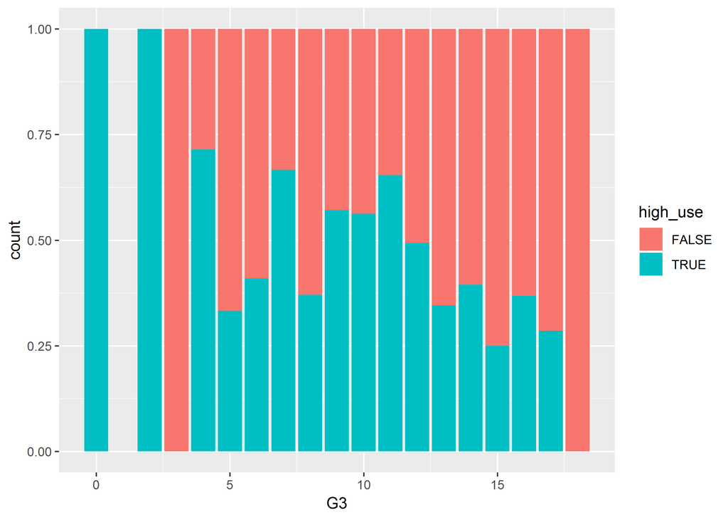

```r
abs <- ggplot(alc, aes(x = G3, fill = high_use)) +
geom_bar(position="fill")
abs
```

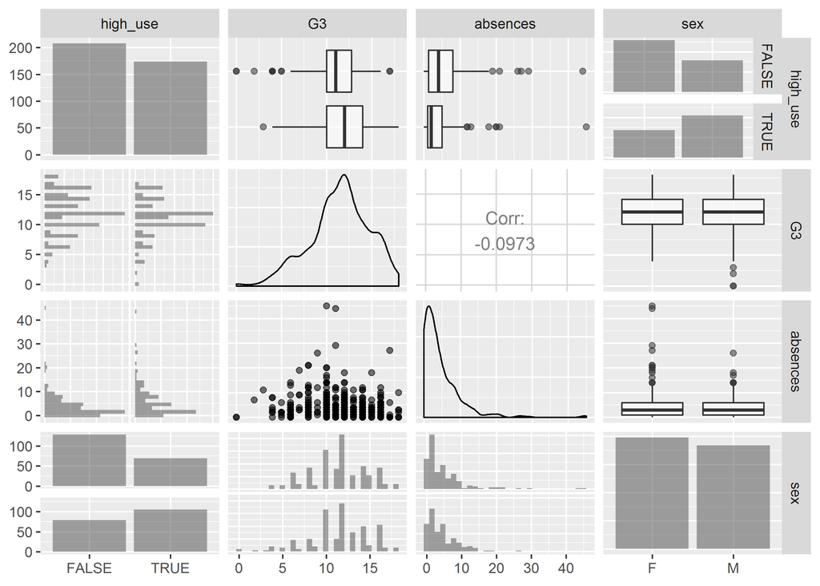

```r
vars <- c("high_use","G3","absences","sex")
ggpairs(alc, columns = vars, mapping = aes(alpha = 0.3), lower = list(combo = wrap("facethist")))
```

- Bocplot show that for males high use is more related to g3 point, for female highuse doesnt really effect.

- From summary we can see that absences and sex are significant variables, G3 is just slightly significant and Pstatus is not at all.

-There are 198 females and 184 male on the data set. propability for a female to be high user is 0.35 and 0.57 for male, so hypothesis was right. From cbind(OR, CI) we can see that odds for men high use are 2.7 times higher then for female.

- from G3 plot we can see that the propability for high use decreases as G3 rises. With one point raise in G3, the odds for high alcohol use decrease by 0.92.

2.5 Pstatus is not significant so it will be dropped.

```r
m <- glm(high_use ~ absences + sex + Pstatus + G3, data = alc, family = "binomial")

m <- glm(high_use ~ absences + sex + G3, data = alc, family = "binomial")
summary(m)
```

```
##
## Call:
## glm(formula = high_use ~ absences + sex + G3, family = "binomial",
##     data = alc)
##
## Deviance Residuals:
##     Min       1Q   Median       3Q      Max
## -2.2624  -1.0324  -0.7392   1.0978   1.8355
##
## Coefficients:
##             Estimate Std. Error z value Pr(>|z|)
## (Intercept) -0.01459    0.42492  -0.034   0.9726
## absences     0.07455    0.02285   3.263   0.0011 **
## sexM         0.99179    0.21822   4.545  5.5e-06 ***
## G3          -0.08616    0.03350  -2.572   0.0101 *
## ---
## Signif. codes:  0 '***' 0.001 '**' 0.01 '*' 0.05 '.' 0.1 ' ' 1
##
## (Dispersion parameter for binomial family taken to be 1)
##
##     Null deviance: 526.53  on 381  degrees of freedom
## Residual deviance: 486.18  on 378  degrees of freedom
## AIC: 494.18
##
## Number of Fisher Scoring iterations: 4
```

```r
coef(m)
```

```
## (Intercept)    absences        sexM          G3
## -0.01459384  0.07455392  0.99179380 -0.08615843
```

```r
confint(m)
```

```
##                   2.5 %      97.5 %
## (Intercept) -0.84873690  0.82171416
## absences     0.03207927  0.12182000
## sexM         0.56786579  1.42426036
## G3          -0.15289901 -0.02123354
```

```r
OR <- coef(m) %>% exp
CI <- confint(m) %>% exp
cbind(OR, CI)
```

```
##                    OR     2.5 %    97.5 %
## (Intercept) 0.9855121 0.4279551 2.2743952
## absences    1.0774034 1.0325994 1.1295508
## sexM        2.6960663 1.7644972 4.1547837
## G3          0.9174489 0.8582164 0.9789903
```

Pstatus was dropped since it was not significant. in the new model:

-Each point in absences raises the odds for 1.08. for 95% of the students one absence point raises high use risk between 1.03 & 1.13.

- In sex its 2.7 times more likely for male to be high user than female. for 95% of the students the coefficients have an effect of 1.76-4.15
- Each point in G3 decreases the risk for high use for 1-0.92. for 95% of the students the one point decreases between 0.86 and 0.98.

3.6

```r
m <- glm(high_use ~ absences + Pstatus + sex + G3, data = alc, family = "binomial")
probabilities <- predict(m, type = "response")
alc <- mutate(alc, probability = probabilities)
alc <- mutate(alc, prediction = alc$probability>0.5)
select(alc, G3, absences, sex, high_use, probability, prediction) %>% tail(10)
```

```
##     G3 absences sex high_use probability prediction
## 373  0        0   M     TRUE   0.7236687       TRUE
## 374  2        7   M     TRUE   0.7936071       TRUE
## 375 12        1   F     TRUE   0.2823117      FALSE
## 376  8        6   F     TRUE   0.4471281      FALSE
## 377  5        2   F    FALSE   0.4306905      FALSE
## 378 12        2   F    FALSE   0.2984561      FALSE
## 379  4        2   F     TRUE   0.4509577      FALSE
## 380  4        3   F    FALSE   0.4704247      FALSE
## 381 13        4   M     TRUE   0.5516064       TRUE
## 382 10        2   M     TRUE   0.5737420       TRUE
```

```r
table(high_use = alc$high_use, prediction = alc$prediction)
```

```
##         prediction
## high_use FALSE TRUE
##    FALSE   151   57
##    TRUE     79   95
```

```r
table(high_use = alc$high_use, prediction = alc$prediction) %>% prop.table() %>% addmargins()
```

```
##         prediction
## high_use     FALSE      TRUE       Sum
##    FALSE 0.3952880 0.1492147 0.5445026
##    TRUE  0.2068063 0.2486911 0.4554974
##    Sum   0.6020942 0.3979058 1.0000000
```

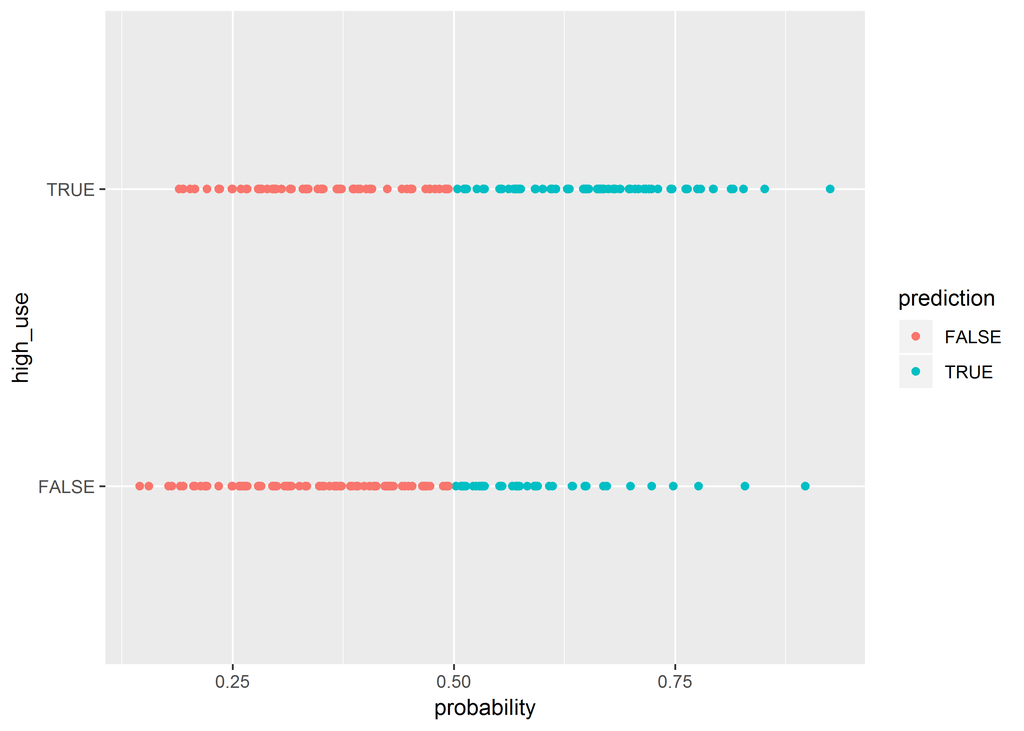

```r
g <- ggplot(alc, aes(x = probability, y = high_use, col=prediction))
g + geom_point()
```

prediction says 0.60 for false, 0.40 for true. high_use is 0.54 for false and 46 for true. I will add failures to model to see what happens

```r
m <- glm(high_use ~ absences + failures + sex + G3, data = alc, family = "binomial")
probabilities <- predict(m, type = "response")
alc <- mutate(alc, probability = probabilities)
alc <- mutate(alc, prediction = alc$probability>0.5)
select(alc, G3, absences, sex, high_use, probability, prediction) %>% tail(10)
```

```
##     G3 absences sex high_use probability prediction
## 373  0        0   M     TRUE   0.7322418       TRUE
## 374  2        7   M     TRUE   0.8001864       TRUE
## 375 12        1   F     TRUE   0.2669667      FALSE
## 376  8        6   F     TRUE   0.4053126      FALSE
## 377  5        2   F    FALSE   0.4649528      FALSE
## 378 12        2   F    FALSE   0.2815204      FALSE
## 379  4        2   F     TRUE   0.5657591       TRUE
## 380  4        3   F    FALSE   0.4153810      FALSE
## 381 13        4   M     TRUE   0.5276033       TRUE
## 382 10        2   M     TRUE   0.5399197       TRUE
```

```r
table(high_use = alc$high_use, prediction = alc$prediction)
```

```
##         prediction
## high_use FALSE TRUE
##    FALSE   158   50
##    TRUE     80   94
```

```r
table(high_use = alc$high_use, prediction = alc$prediction) %>% prop.table() %>% addmargins()
```

```
##         prediction
## high_use     FALSE      TRUE       Sum
##    FALSE 0.4136126 0.1308901 0.5445026
##    TRUE  0.2094241 0.2460733 0.4554974
##    Sum   0.6230366 0.3769634 1.0000000
```

define a loss function (mean prediction error)/proportion of inaccurately classified individuals (= the training error):

```r
loss_func <- function(class, prob) {
  n_wrong <- abs(class - prob) > 0.5
  mean(n_wrong)
}
loss_func(class = alc$high_use, prob = alc$probability)
```

```
## [1] 0.3403141
```

The training error is 0.34, so it´s worse then the one in dataCamp exercises.

Bonus:

```r
loss_func(class = alc$high_use, prob = alc$probability)
```

```
## [1] 0.3403141
```

```r
library(boot)
cv <- cv.glm(data = alc, cost = loss_func, glmfit = m, K = 10)
cv$delta[1]
```

```
## [1] 0.3612565
```